# Hypothesis Testing II

## Simulation

Randomization

vs.

Simulation

## The procedure

1. Let a coin flip represent selecting a random American. Heads = in favor.
2. Flip a coin 75 times and compute the proportion of heads.
3. Repeat step 2 many many times, logging the sample proportions

```r
library(mosaic)
p_hats <- do(10000) * rflip(n = 75)
head(p_hats)
```

```
##    n heads tails prop
## 1 75    35    40 0.47
## 2 75    42    33 0.56
## 3 75    42    33 0.56
## 4 75    41    34 0.55
## 5 75    43    32 0.57
## 6 75    36    39 0.48
```

## The Hypotheses

Let \(p\) be the true proportion of Americans who favor same-sex marriage.

\[H_0: p = 0.5\]

\[H_A: p \ne 0.5\]

## The Data

The *observed test statistic* was

\[\hat{p} = 0.66\]

## The Null Distribution

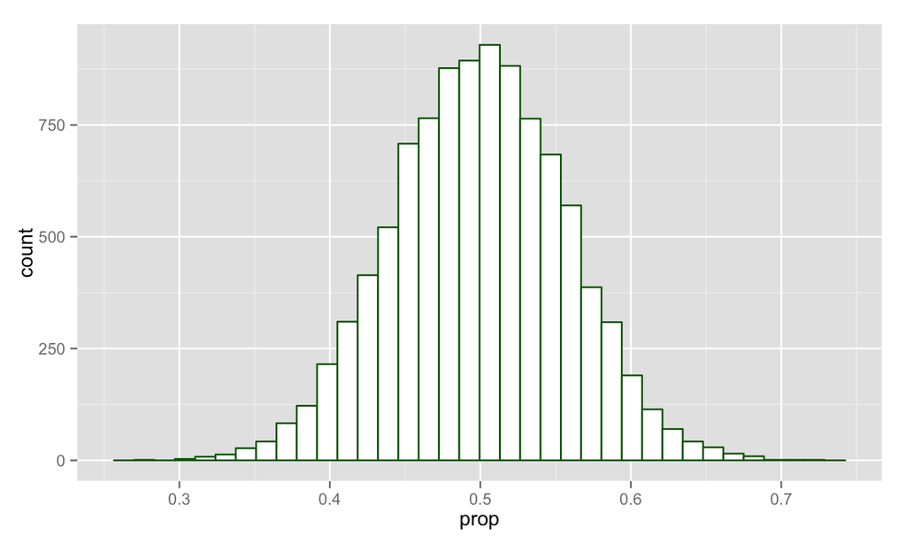

```r
qplot(x = prop, data = p_hats, geom = "bar",
      binwidth = .0135, fill = I("white"), col = I("darkgreen"))
```

## The Null Distribution

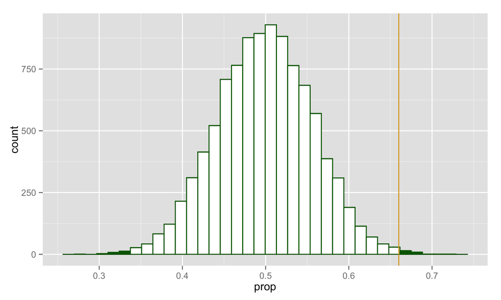

\[p.val \approx 0.006\]

## The decision

\[ \alpha = .05; \quad p.val \approx .006 \]

Since

\[ p.val < \alpha\]

we find the data is inconsistent with our model, aka, we reject the null hypothesis.

## Ways to find a Null Distribution

1. Randomization
2. Simulation
3. Probability Theory

## Probability Theory

Let \(X\) be the total number of people in a sample of size 75 that favor same-sex marriage if the true population proportion that favor is 0.5.

\(x_{obs} = 75 \times 0.66 = 50\)

What is \(P(X > x_{obs})\)?

## Let's simplify

Let \(X\) be the total number of people in a sample of size 3 that favor same-sex marriage if the true population proportion that favor is 0.5.

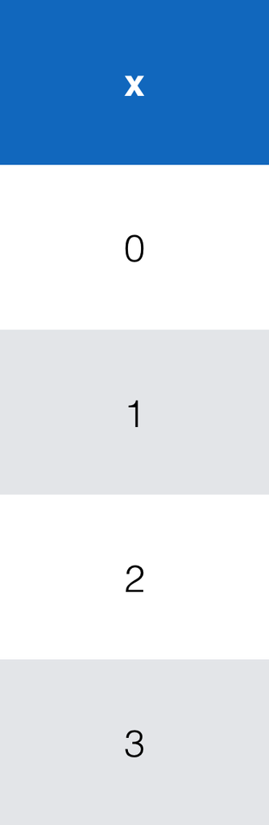

## Let's simplify

Let \(X\) be the total number of people in a sample of size 3 that favor same-sex marriage if the true population proportion that favor is 0.5.

[figure not shown]

## Let's simplify

Let \(X\) be the total number of people in a sample of size 3 that favor same-sex marriage if the true population proportion that favor is 0.5.

[figure not shown]

## Binomial distribution

The sum of independent trials that succeed with probability \(p\) will be distributed as a binomial random variable, X;

\[ X \sim Bin(n, p) \]

\[ P(X = x) = \binom{n}{x}p^x(1-p)^{n-x} \]

## Binomial Distribution

Let \(X\) be the total number of people in a sample of size 75 that favor same-sex marriage if the true population proportion that favor is 0.5.

\(x_{obs} = 75 \times 0.66 = 50\)

What is \(P(X > x_{obs})\)?

## The Null Distribution

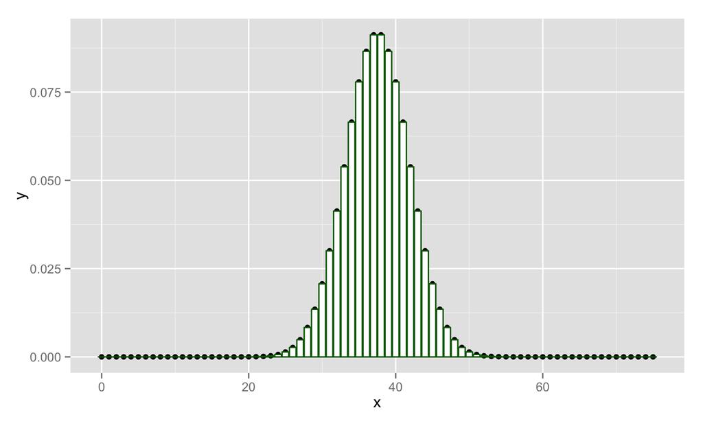

\[p.val = 0.002\]